# STAT3040 : Time Series Analysis 2016 Lab 11

### Pre-Whitening

1. The basic problem that were considering is the construction of a lagged regression in which we predict a $Y_t$ variable at time $t$ using lags of an $X_t$ variable (including lag $0$) and lags of the $Y_t$ variable.
2. We have already introduced the cross-correlation function as an aid to the identification of the model.
3. One dificulty is that the CCF is affected by the time series structure of the $X_t$ variable and any `in common’ trends the time series $X_t$ and $Y_t$ may have over time.
4. One strategy for dealing with this difficulty is called pre-whitening. The steps are:
   1. Determine a time series model for the $X_t$ variable and store the residuals from this model.
   2. Filter the $Y_t$ variable series using the $X_t$ variable model (using the estimated coe cients from step (a)). In this step we find differences between observed $Y_t$ values and ‘estimated’ $Y_t$ values based on the $X_t$ variable model.
   3. Examine the CCF between the residuals from Step (a) and the filtered $Y_t$ values from Step (b). This CCF can be used to identify the possible terms for a lagged regression.
5. Generate a time series from the AR(1) model $X_t = 0.8X_{t-1} + \mathcal{W}_t$:

```r
x <- arima.sim(list(c(1,0,0), ar=0.8), n=200)
```

6. Generate the time series $Y_t = 10 + 0.6X_{t-2} + 1.2X_{t-4} + \mathcal{V}_t$ where $\mathcal{V}_t$ is a Guassian White Noise series with mean zero and variance one:

```r
z <- ts.intersect(x, lag(x,-2), lag(x,-4))
dim(z)
```

```
## [1] 196   3
```

```r
y <- 10 + 0.6*z[,2] + 1.2*z[,3] + rnorm(196,0,1)
```

7. Fit an ARIMA model to $X_t$:

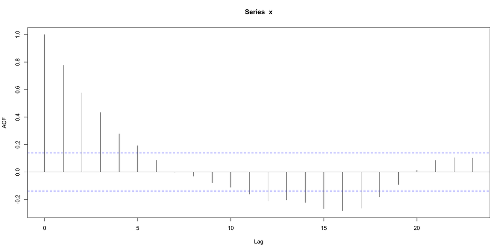

```r
acf(x)
```

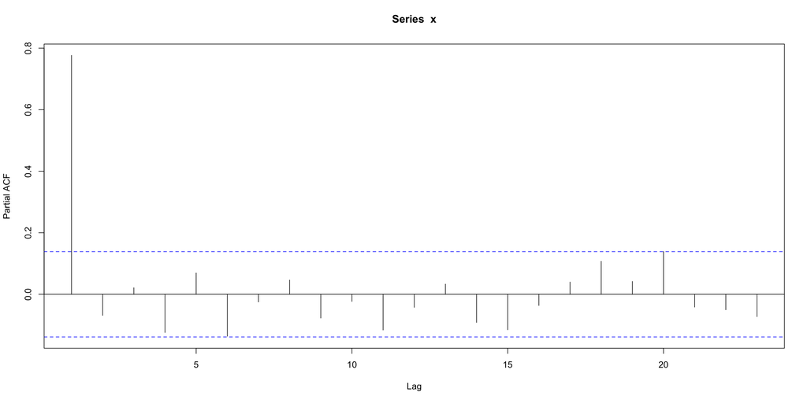

```r
pacf(x)
```

```r
fit <- arima(x, c(1,0,0))
fit$coef
```

```
##       ar1 intercept
## 0.7782770 0.3893668
```

8. Filter the time series $Y_t$ using the model for $X_t$:

```r
pwy <- filter(y, filter = c(1,-fit$coef[1]), sides = 1)
head(pwy)
```

```
## [1]          NA  4.96139074  0.04287815  1.53595556  1.23021098 -0.37553500
```

9. Plot the cross-correlation function between the residuals of the tted model for the time series $X_t$ and the filtered model for $Y_t$:

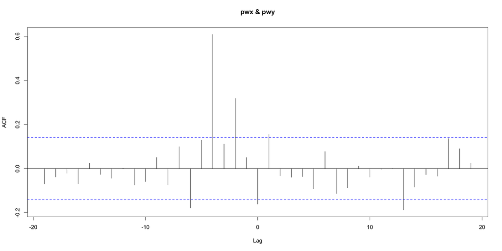

```r
pwx <- fit$residuals
ccf(pwx,pwy, na.action=na.omit)
```

10. Fit a lagged-regression model for the time series $Y_t$:

```r
fit2 <- lm(y~z[,2]+z[,3])
summary(fit2)
```

```
##
## Call:
## lm(formula = y ~ z[, 2] + z[, 3])
##
## Residuals:
##     Min      1Q  Median      3Q     Max
## -3.5195 -0.5322  0.0465  0.6523  2.5797
##
## Coefficients:
##             Estimate Std. Error t value Pr(>|t|)
## (Intercept) 10.01806    0.07629  131.32   <2e-16 ***
## z[, 2]       0.61126    0.05256   11.63   <2e-16 ***
## z[, 3]       1.19397    0.05265   22.68   <2e-16 ***
## ---
## Signif. codes:  0 '***' 0.001 '**' 0.01 '*' 0.05 '.' 0.1 ' ' 1
##
## Residual standard error: 1.044 on 193 degrees of freedom
## Multiple R-squared:  0.8842, Adjusted R-squared:  0.883
## F-statistic: 736.5 on 2 and 193 DF,  p-value: < 2.2e-16
```

```r
fit3 <- arima(y, c(0,0,0), xreg = cbind(z[,2], z[,3]))
fit3$coef
```

```
##  intercept     z[, 2]     z[, 3]
## 10.0180609  0.6112573  1.1939665
```